# Les régions du Québec vs Montréal

[figure not shown]

```r
# Charger la bibliothèque knitr
library(knitr)

# Afficher l'image
include_graphics("C:/Users/Alexa/OneDrive/Bureau/AlexandreChayer.github.io/projet_session/image/election_2022.png")
```

## Question de recherche et hypothèse

Avec ce constat, nous pouvons nous poser la question suivante : est-ce que les citoyens résidants en banlieues et dans les régions rurales ont un comportement électoral différent des citoyens restant en ville?

À l’aide de l’outil de recherche assisté par l’intelligence artificielle Elicit, nous avons effectué une courte revue de littérature. Elicit produit lui-même un résumé de littérature. Voici donc la revue de littérature produite par Elicit et traduit avec le logiciel de traduction Deepl :

Les recherches sur le comportement électoral au Québec révèlent des différences significatives entre les zones urbaines et suburbaines. Depuis les années 1980, les résidents des centres-villes ont tendance à voter plus à gauche, tandis que les banlieusards se tournent de plus en plus vers la droite (Walks, 2005, 2007). Ce clivage urbain-suburbain est plus prononcé lorsque l’on utilise des frontières basées sur la forme urbaine plutôt que sur les frontières municipales (Walks, 2007). La région de Québec, en particulier, a montré une plus forte tendance à élire des représentants conservateurs depuis les années 1970 (Daoust, 2017 ; Villeneuve et al., 2008). Si les différences régionales sont importantes pour expliquer les habitudes de vote, la classe sociale joue également un rôle significatif dans la formation des attitudes et des comportements politiques (Ornstein et al., 1980). Le Parti Québécois a gagné le soutien de divers groupes socio-économiques, les groupes à statut plus élevé montrant parfois un soutien plus fort, en particulier en dehors de Montréal (Hamilton & Pinard, 1976). Ces différences régionales et urbaines-suburbaines dans le comportement électoral ne peuvent pas être entièrement expliquées par les seuls facteurs sociodémographiques (Gidengil et al., 1999).

Selon la littérature et les résultats des élections de 2022, nous pensons que nous devrions observer une grosse différence dans l’appui de la CAQ et le PQ entre les banlieues et les régions versus la ville de Montréal. De plus, nous croyons aussi que le PLQ et QS devrait être beaucoup plus populaire en région métropolitaine que partout à l’extérieur du Québec.

## Collecte de donnée

Avant de nous lancer dans un sondage à l’échelle nationale, nous avons observé les données déjà disponibles en ligne. Nous avons découvert que les données sur les dons aux partis politiques sont accessibles sur le site du Directeur général des élections. Nous croyons que les données aux dons reçus par les partis politiques pourraient être un bon indicateur de l’appui géographique des différentes options politiques. LA CAQ et le PQ devraient avoir plus de dons de l’extérieur de Montréal et le PLQ et QS devrait avoir plus de dons en provenance de Montréal que du reste des municipalités québécoises. Nous avons donc téléchargé le ficher CSV disponible, ce qui nous parmi d’avoir accès à plus de 25 000 données sur tous les dons qui ont été faits aux différents partis politiques depuis l’entrée en vigueur du registre.

## Analyse et visualisation des données

Afin d’illustrer les données et ainsi confirmer ou infirmer notre hypothèse, nous avons importé nos données dans R afin de produire un graphique démontrant la différence pour chaque parti entre lors d’un montréalais versus les dons provenant de l’extérieur de Montréal. Nous avons utilisé la fonction ggplot du forfait de la Tidyverse afin de produire le graphique. De plus, nous avons fait le choix éditorial de seulement choisir les 4 partis représenter à l’Assemblée nationale. De plus, nous avons choisi de sortir les données seulement pour l’année 2023, comme c’était la seule année complète de terminer depuis l’élection de 2022.

### Visualtion des données

```r
# Charger la bibliothèque nécessaire
library(tidyverse)
# Remplacer par le chemin du fichier CSV
file_path <- "C:/Users/Alexa/OneDrive/Bureau/AlexandreChayer.github.io/projet_session/data/contributions-pro-fr.csv"
  # Chemin vers votre fichier

# Charger le fichier CSV en spécifiant le séparateur ";"
df <- read_delim(file_path, delim = ";", locale = locale(encoding = "latin1"), col_names = TRUE)
```

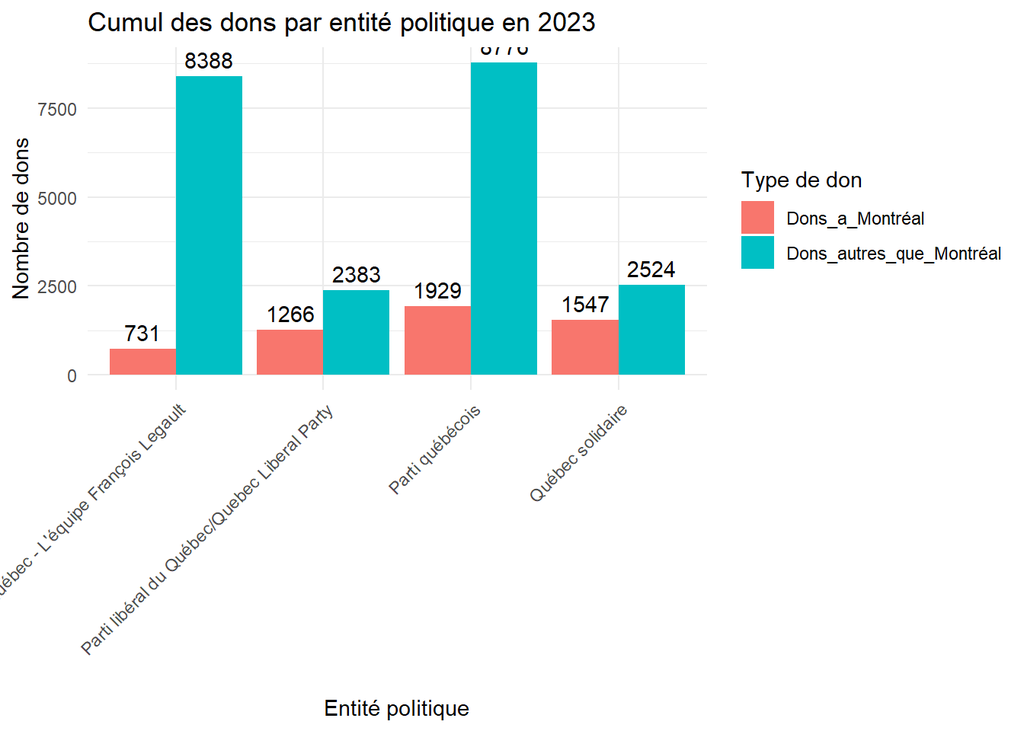

```r
# Filtrer les données pour l'année 2023 et les entités politiques spécifiées
entities_2023 <- c("Coalition avenir Québec - L'équipe François Legault",
                   "Parti libéral du Québec/Quebec Liberal Party",
                   "Québec solidaire",
                   "Parti québécois")

df_2023_filtered <- df %>%
  filter(`Année financière` == 2023, `Entité politique` %in% entities_2023)

# Créer une nouvelle colonne pour séparer les dons à Montréal et les autres dons
df_2023_filtered <- df_2023_filtered %>%
  mutate(
    Montreal = if_else(`Municipalité` == "Montréal", 1, 0),
    Non_Montreal = if_else(`Municipalité` != "Montréal", 1, 0)
  )

# Cumuler les dons pour chaque entité politique et chaque catégorie
donations_combined <- df_2023_filtered %>%
  group_by(`Entité politique`) %>%
  summarise(
    Dons_a_Montréal = sum(Montreal),
    Dons_autres_que_Montréal = sum(Non_Montreal)
  )

# Créer un graphique avec ggplot2
donations_combined %>%
  pivot_longer(cols = starts_with("Dons"), names_to = "Type_don", values_to = "Nombre_de_dons") %>%
  ggplot(aes(x = `Entité politique`, y = Nombre_de_dons, fill = Type_don)) +
  geom_bar(stat = "identity", position = "dodge") +
  geom_text(aes(label = Nombre_de_dons), position = position_dodge(width = 0.9), vjust = -0.5) +  # Afficher les valeurs au-dessus des barres
  labs(
    title = "Cumul des dons par entité politique en 2023",
    x = "Entité politique",
    y = "Nombre de dons",
    fill = "Type de don"
  ) +
  theme_minimal() +
  theme(axis.text.x = element_text(angle = 45, hjust = 1))  # Rotation des labels pour les entités politiques
```

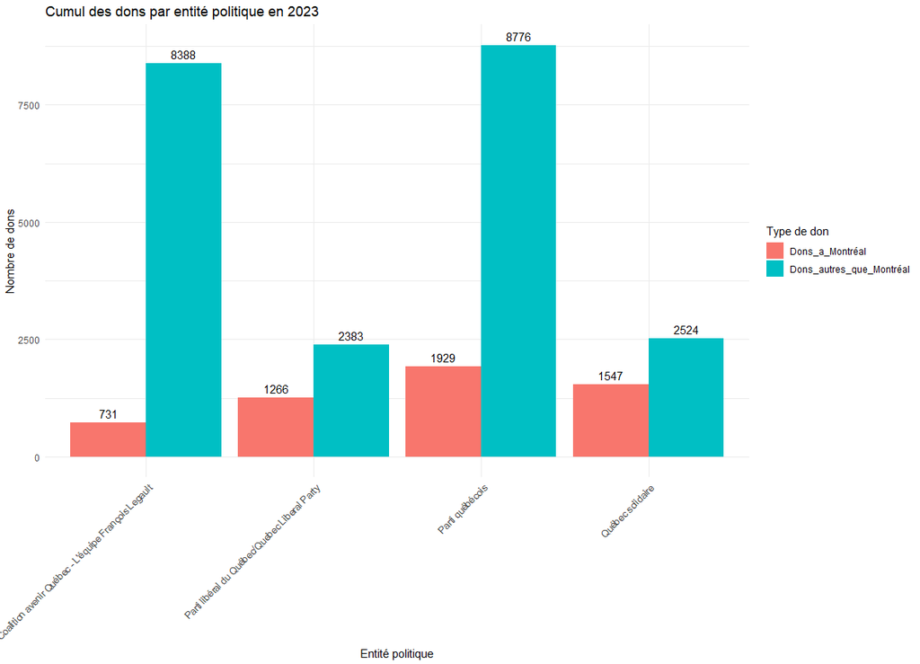

```r
# Charger la bibliothèque knitr
library(knitr)

# Afficher l'image
include_graphics("C:/Users/Alexa/OneDrive/Bureau/AlexandreChayer.github.io/projet_session/image/graphique_dons.png")
```

## Analyse des résultats

Le graphique nous permet de confirmer en partie notre hypothèse. En effet, comme prévu, la CAQ et le PQ font le plein d’argent en dehors de la ville de Montréal. Cependant, notre hypothèse concernant le PLQ et QS semble s’infirmer. En effet, comme le démontre la visualisions de données 1266 dons ont été faits au PLQ provenant de la Ville de Montréal versus 2383. La même chose s’est produite du côté de QS avec 1547 dons à Montréal versus 2524 à l’extérieur de Montréal. Cette différence chez le PLQ s’explique peut-être par comment les données sont codées dans la base du DGEQ. En effet, nous avons fait une analyse en fonction de la municipalité, or, sur l’île de Montréal, surtout dans l’ouest de l’île, il y a plusieurs municipalités qui ne font pas partie de la Ville de Montréal. En effet, des municipalités telles Lasalle, Dorval, Westmount, Mont-Royal, etc. sont codées comme des municipalités différentes que Montréal. Donc, un biais dans notre recherche est que les dons à Montréal ne représentent pas les dons faits sur l’île comme telle, mais bien dans la municipalité de Montréal. Ceci explique probablement pourquoi le PLQ a plus de dons hors Montréal comme leur base se retrouve majoritairement dans l’ouest de l’île. Pour QS, nous ne croyons pas que ce biais à la même influence que pour le PLQ. Pour QS, ils ont 3 députés en région soit 2 à Québec et 1 à Sherbrooke. Cela explique peut-être pourquoi ils ont près de 1000 donateurs de plus à l’extérieur de Montréal. Un deuxième biais dans notre recherche est que nous n’avons pas pris en considération les milieux urbains en dehors de Montréal. Comme QS a 3 députés à l’extérieur de Montréal, mais dans des milieux urbains, nous aurions modifier notre critère et ajouter les zones urbaines telles Québec et Sherbrooke et ainsi nous pourrions voir comment QS est capable de lever du financement en dehors des régions urbaines.

## Discussion

Pour conclure, nous avons décidé d’utiliser Elicit, R et R Markdown afin de produire ce travail en raison des besoins que nous avions lors de cette recherche. En effet, Elicit nous a permis de faire rapidement notre revue de littérature. Il est dommage qu’un outil aussi génial soit caché derrière un Paywall ce qui est un peu en contradiction avec les valeurs de notre cours. Cependant, comme l’université nous permet d’avoir accès gratuitement, c’est un outil qui vaut la peine d’être utilisé en raison de sa puissance et de sa rapidité. Ensuite, nous avons utilisé R afin de faire la visualisions de nos données. En effet, R était selon moi le meilleur outil pour ce que nous avions à faire. Nous avions énormément de données à traiter, mais je crois qu’il n’était pas nécessaire d’utiliser un langage de programmation plus puissant comme Python afin d’effectuer cette recherche. Pour terminer, nous avons utilisé R et Markdown afin de rédiger cette recherche principalement pour la versatilité de l’outil. En effet, nous allons pouvoir exporter la recherche en HTML afin de la publier sur notre site web, chose qui n’aurait pas été possible à partir des autres outils de rédaction comme Latex.

En bref, ce qui nous a portés à choisir les outils était principalement la facilité d’utilisation des outils. En effet, le but n’était pas de faire un travail très poussé, mais plutôt démontrer que nous sommes capables d’utiliser différents outils dans un contexte de recherche. Afin de respecter la philosophie du partage des connaissances et de l’Open source tel qu’enseigné par Adrien, il aurait été cool d’utiliser un logiciel Open source afin de faire la revue de littérature, mais la paresse l’a remporté sur les bonnes valeurs. En échange, nous avons utilisé R qui va permettre aux milliers de lecteurs de reproduire exactement les mêmes résultats.